# Sampling, Linear Regression, and Uncertainty

Carolina Torreblanca

University of Pennsylvania

**Global Development**: Intermediate Topics in Politics, Policy, and Data

PSCI 3200 - Spring 2026

## Housekeeping

- You have two assignments next week!

## Today’s Roadmap

1. Targeting Population Parameters with Sample Estimates
2. The Uncertainty in Sample Estimates
3. Linear Regression and its Parameters
4. Quantifying Uncertainty in Linear Regression’s Estimated Parameters

## From sample to population

- Often we want to know some characteristic about a population of interest
- But we only have a sample of that population
- How do we make inferences about the population with what we learn from our sample?

## From sample to population

- The first step is to make sure our sample is representative of the population
  - What do we mean by this?
  - Why is it important?
- How can we achieve representativeness?
- Beware! We not only need to *sample* a representative group of individuals, we also need a representative group of them to *answer* our questions

## It’s not all about sample size!

- 1936 Presidential Election in the US: FDR vs Alf Landon
- A newspaper called the Literary Digest ran a survey and asked 10 million (!!!) Americans who they would vote for
  - 2.4 million of them answered

## It’s not (all) about sample size!

[figure not shown]

## Empirical Example: Brexit

- Data from a random sample of British citizens: the British Electoral Survey
- We want to learn the probability that a British citizen supports Brexiting in the **country.**
  - This is a population parameter
- Such probability is the same in expectation as the proportion of pro-brexiting citizens
  - Why?

## Empirical Example: Brexit

```r
brex <- read.csv(here::here("./slides/code/BES.csv"))
str(brex)
```

```
'data.frame':   30895 obs. of  4 variables:
 $ vote     : chr  "leave" "leave" "stay" "leave" ...
 $ leave    : int  1 1 0 1 NA 0 1 1 1 1 ...
 $ education: int  3 NA 5 4 2 4 3 2 3 4 ...
 $ age      : int  60 56 73 64 68 85 78 51 59 68 ...
```

```r
table(brex$vote, useNA = "always")
```

```
   don't know         leave          stay wouldn't vote          <NA>
         2314         13692         14352           537             0
```

```r
brex$exit <- ifelse(brex$vote=="leave", 1,
                ifelse(brex$vote == "stay", 0, NA))
prop.table(table(brex$exit))*100
```

```
       0        1
51.17672 48.82328
```

## Empirical Example: Brexit

- Random Variable: the outcome of some process where there’s uncertainty
  - Think of flipping a coin: we do not know if the result of a single flip will be heads or tails, but we know that with p = .5 it will be the former
- *“Support of Brexit”* is a Random Variable:
  - $Support \sim \text{Bernoulli}(p)$
- Where $E(Support) = p$

## Empirical Example: Brexit

- We want to know what $p$ is!
- But it is a *population parameter* and we only have a sample
- We can estimate $\hat{p}$ by doing

```r
brex <- dplyr::filter(brex, is.na(exit)==F)
(phat <- mean(brex$exit, na.rm =T))
```

```
[1] 0.4882328
```

- To see why, imagine a fair coin toss. How many Heads do you expect after flipping the coin 100 times?

## Sampling Distribution of $\hat{p}$

- On expectation, our sample $E[\hat{p}] = p$
  - This property is called unbiasedness
  - As our sample size increases, our $\hat{p}$ converges in probability to p
- But if our sample were slightly different, we would have gotten a different $\hat{p}$!
  - We need to account for this uncertainty!
- Let’s simulate the different sample means we would have gotten if our sample changed slightly:

## Sampling Distribution of $\hat{p}$

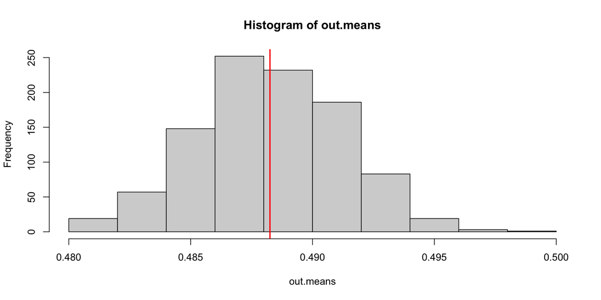

```r
require(tidyverse)
set.seed(7)

out.means <- c()
for (i in 1:1000) {
  temp_dat <- sample_n(brex, nrow(brex), replace = T)
  out.means[i] <- mean(temp_dat$exit, na.rm = T)
  rm(temp_dat)
}

hist(out.means)
abline(v = mean(out.means), col = "red", lwd = 2, add = T)
```

## Sampling Distribution of $\hat{p}$

- That’s just a normal distribution!
- **All normal distributions can be described by their mean and their standard deviation**
- This one is called “sampling distribution of the sample mean”
  - Centered around our estimate $\hat{p}$
  - $SE = \sqrt{\frac{Var (Support)}{n}}$
- Knowing it is a normal distribution helps us quantify the *uncertainty* in our estimates

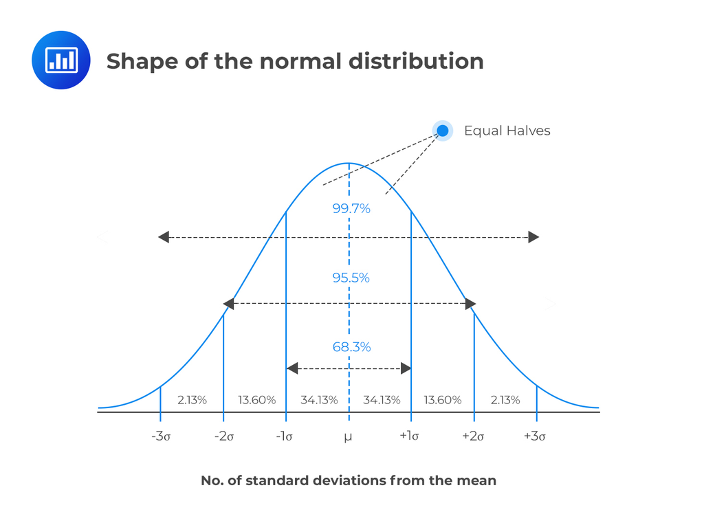

## Standard Errors

- The standard deviation of the sampling distribution of an estimator is called “standard error”
- By calculating the standard error we can know the shape of the sampling distribution. This helps us do two important things:
  1. Construct confidence intervals (what is the range within which the true value is likely to be?)
  2. Do hypothesis testing (p-values and statistical significance)

## Confidence Intervals

- Range of values that **likely** includes the true value of our parameter of interest
  - The range that includes a pre-specified proportion of the density of the sampling distribution
- Interpretation: “With X% confidence, the true parameter is within the confidence interval”
  - More specifically “If I drew millions of samples and constructed a confidence interval for each one, my true parameter would be inside the CI X% of the times”

## Confidence Intervals

- Because of the properties of the normal distribution, we know that 95% of the density will be within the following range:

$$\begin{align*}
CI_{95\%} = \hat{p} - 1.96 \times \sqrt{\frac{Var (Support)}{n}},\\
\hat{p} + 1.96 \times \sqrt{\frac{Var (Support)}{n}}
\end{align*}$$

## Computing CI’s: Example

```r
# standard deviation of the sampling distribution computed with the formula
se <- round(sqrt(var(brex$exit, na.rm = T)/nrow(brex)),3)
# An analytic solution to the confidence interval
(ci_95 <- c(phat - (1.96*se), phat + (1.96*se)))
```

```
[1] 0.4823528 0.4941128
```

```r
# We can check that it's the same as the interval that leave 95% of the mass inside
# of the sampling distribution
quantile(out.means, c(.025, .975))
```

```
     2.5%     97.5%
0.4824196 0.4939738
```

## Linear Regression

- We can think of the parameters of a linear regression in the same way.

$$\begin{equation*}
Y_i = \alpha + \beta X_i + \varepsilon_i
\end{equation*}$$

- $\alpha$ an intercept, common to all units.
- $\beta$ the slope, common to all units.
- We need to describe the relationship between X and Y with a line using information from our sample

## Linear Regression: Intuition

- Our data includes the outcome $y_i$ and our explanatory variable $x_i$
- But we can draw infinite lines through those points
- How to choose the correct $\widehat{\beta}$ and $\widehat{\alpha}$, like we chose the correct $\widehat{p}$?

## Linear Regression: Intuition

- If we have a slope and an intercept, for every $X_i$, the equation of a line gives us a predicted $Y_i$, or $\widehat{Y_i}$
- So, for each plausible estimates of $\widehat{\beta}$ and $\widehat{\alpha}$ we can calculate the *prediction error*

$$\begin{align*}
\hat{\varepsilon}_i =& Y_i - \hat{Y_i} \\
\hat{\varepsilon}_i =& Y_i - \hat{\alpha} - \hat{\beta} x_i
\end{align*}$$

## Linear Regression: Intuition

- If we add up the prediction error for each observation, we get the *S*um of *S*quared *R*esiduals

$$\begin{equation*}
SSR = \widehat{\varepsilon}^2 = (Y_i - \widehat{\alpha} - \widehat{\beta}X_i)^2
\end{equation*}$$

- Minimizing this objective yields the “ordinary least squares” (OLS) estimates of $\alpha$ and $\beta$

## Linear Regression: Simulation

```r
# Simulated data
set.seed(8)
# TRUE alpha and beta
alpha <- 5
beta <- -.216
x <- rnorm(100, 4, .8) #
error <- rnorm(100, 0, 1)
# relationship is linear by construction because I'm simulation god!!
y <- alpha + (beta*x) + error
```

## Linear Regression: Simulation

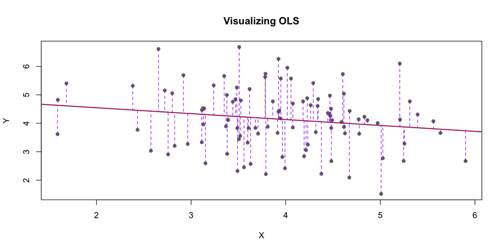

```r
# Fit linear model
model <- lm(y ~ x)
# Predict $y_hat$ or the expected y given the model and x
y_pred <- predict(model)
# Plot the data
plot(x, y, main="Visualizing OLS", xlab="X", ylab="Y", pch=16, col="gray45")
# Add best fit line
abline(model, col="maroon", lwd=2)
# Draw vertical lines showing each prediction error
segments(x, y, x, y_pred, col="purple", lty=2)
```

## Linear Regression: Interpretation

- Why are $\hat{\beta}$ and $\hat{\alpha}$ different from $\alpha$ and $\beta$?

```
Call:
lm(formula = y ~ x)

Residuals:
    Min      1Q  Median      3Q     Max
-2.4061 -0.8055  0.1533  0.6918  2.4457

Coefficients:
            Estimate Std. Error t value Pr(>|t|)
(Intercept)   4.9658     0.5027   9.879   <2e-16 ***
x            -0.2082     0.1251  -1.664   0.0993 .
---
Signif. codes:  0 '***' 0.001 '**' 0.01 '*' 0.05 '.' 0.1 ' ' 1

Residual standard error: 1.074 on 98 degrees of freedom
Multiple R-squared:  0.02748,   Adjusted R-squared:  0.01755
F-statistic: 2.769 on 1 and 98 DF,  p-value: 0.09932
```

```
         x
-0.2081563
```

```
[1] 0.1250993
```

## Linear Regression

- Estimates of $\hat{\beta}$ and $\hat{\alpha}$ have uncertainty
- They have their own sampling distributions!
  - CLT: They are also normal
- We can use what I know about normal distributions to quantify their uncertainty
- We can construct confidence intervals in the exact same way!
- Or do hypothesis tests

## Hypothesis Testing and P-values

- We are often interested in determining whether the true parameter is different from zero with a pre-specified level of confidence

$$\begin{align*}
H_0: \beta = 0 \\
H_1: \beta \neq 0
\end{align*}$$

- We are going to reject $H_0$ in favor of $H_1$ if we are sufficiently confident we aren’t making a (type I) mistake

## P-value

1. Assume the true effect/parameter is 0
2. “Draw” the sampling distribution of the parameter
   - Remember we know that its sd = se
3. Calculate the probability of observing an *estimate* at least as extreme as the one you observed with your sample if the true parameter is zero
4. If you are doing a two-tailed test, use absolute value

## P-value

- Simulated data to visualize the p-value

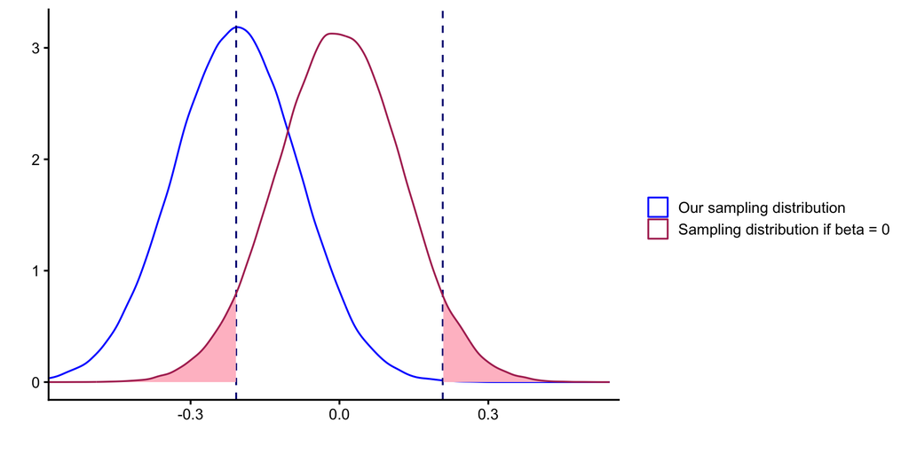

## Statistical Significance

- If you are using a level of statistical significance of 95%, you reject $H0: \beta = 0$ if $\text{p-value} \leq .05$
- If you are using a level of statistical significance of 99%, you reject $H0: \beta = 0$ if $\text{p-value} \leq .01$
- When we have estimates with a p-value less or equal to that, we say our coefficient is “statistically significant”
- It just means we are sure enough the parameter is different from zero
- In papers, they report this with different number of stars!

## Statistical Significance

- In our example, would we reject $H0: \beta = 0$ with 90% confidence? With 95% confidence? With 99%?

```r
summary(model)
```

```
Call:
lm(formula = y ~ x)

Residuals:
    Min      1Q  Median      3Q     Max
-2.4061 -0.8055  0.1533  0.6918  2.4457

Coefficients:
            Estimate Std. Error t value Pr(>|t|)
(Intercept)   4.9658     0.5027   9.879   <2e-16 ***
x            -0.2082     0.1251  -1.664   0.0993 .
---
Signif. codes:  0 '***' 0.001 '**' 0.01 '*' 0.05 '.' 0.1 ' ' 1

Residual standard error: 1.074 on 98 degrees of freedom
Multiple R-squared:  0.02748,   Adjusted R-squared:  0.01755
F-statistic: 2.769 on 1 and 98 DF,  p-value: 0.09932
```

## Summing Up: 2 Takeaways

- The representative-ness of our samples is crucial to make inferences abt. population
  - The more observations we have, the better “powered” we are to detect small effects
  - But sample size does not substitute for representative-ness
- Statistical significance is important but it is NOT a measure of **SCIENTIFIC** importance
  - Statistical significance just means an effect or difference is likely NOT to be zero